# act_report

[figure not shown]

"Data in the 21st Century is like Oil in the 18th Century: an immensely, untapped valuable asset. Like oil, for those who see Data’s fundamental value and learn to extract and use it there will be huge rewards." Wired.com

Data like oil required alot of processing before arriving at the end result. Being a student of Udacity I was able to embark on the most challenging data wrangling process I have ever done. Using Python and its libraries, I gathered data from a variety of sources and in a variety of formats, assess its quality and tidiness, then clean it.

The dataset I use is the tweet archive of Twitter user @dog_rates, also known as WeRateDogs. WeRateDogs is a Twitter account that rates people's dogs with a humorous comment about the dog. These ratings almost always have a denominator of 10. The numerators, though? Almost always greater than 10. 11/10, 12/10, 13/10, etc. WeRateDogs has over 4 million followers and has received international media coverage.

##### Gathering

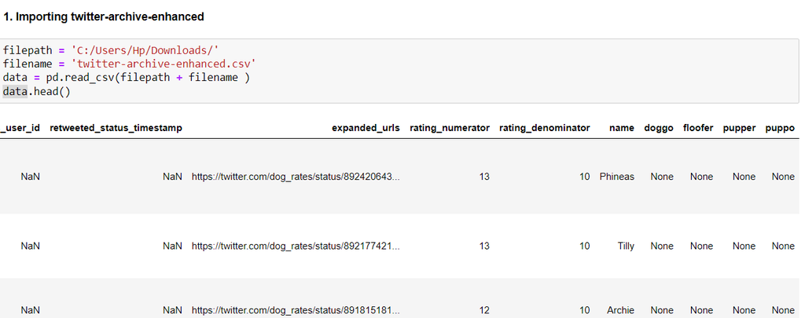

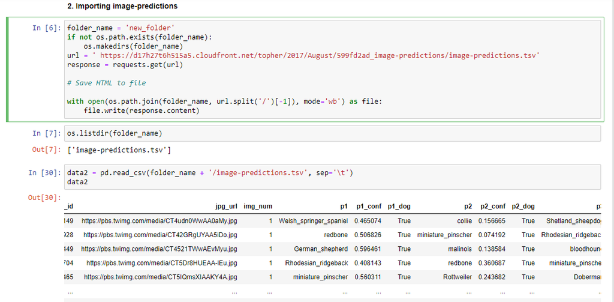

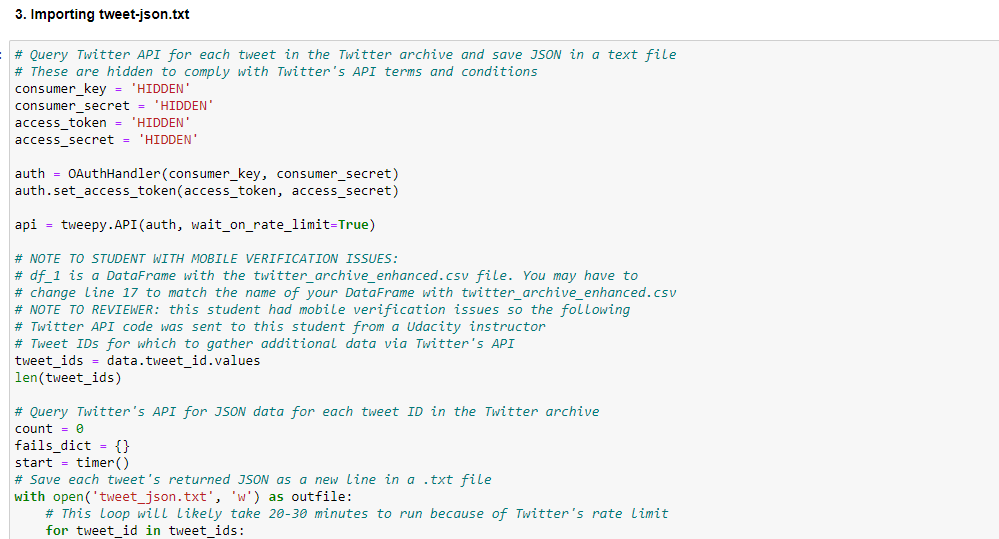

[figure not shown]

##### Accessing.

After uploading the datas the data were accessed both virtually and programmatically to detect quality and tidiness issue in the dataset. 8 quality issues were dictected and 2 tidiness issues were addressed.

##### Cleaning

Once the issues have been detected, then i started cleaning the datas to resolve the issue identified during the accessing stage.

##### Visualization and Insight

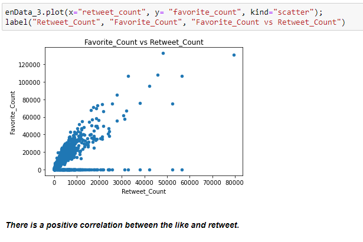

The insight from the scatter plot is that there is dependency between retweet and likes(favorite).

There is a positive correlation between the two features.

[figure not shown]